# Transformations and Nonlinearity

2015-07-27

## Topics

So far, we have focused on regression involving linear coefficients for numeric independent variables. Today, we turn our attention to new classes of regression terms:

- transformations
- polynomials
- standardization

## Goals

After class today you will be able to

- illustrate regression with transformed variables in words, pictures, and equations
- illustrate regression with polynomial variables in words, pictures, and equations
- interpret standardized regression coefficients

## Transformations

[figure not shown]

If you fit a linear model to data the residual plots look awful, one strategy to regain a valid model is to transform your data.

## Example 1: Cleaning crews

A building maintenance company is planning to submit a bid to clean corporate offices. How much should they bid? They'd like to be able to cover the job with a team of 4 crews and a team of a 16 crews, but they want to be sure. To make a good prediction, they collected data on how many crews were required over a sample of 53 days.

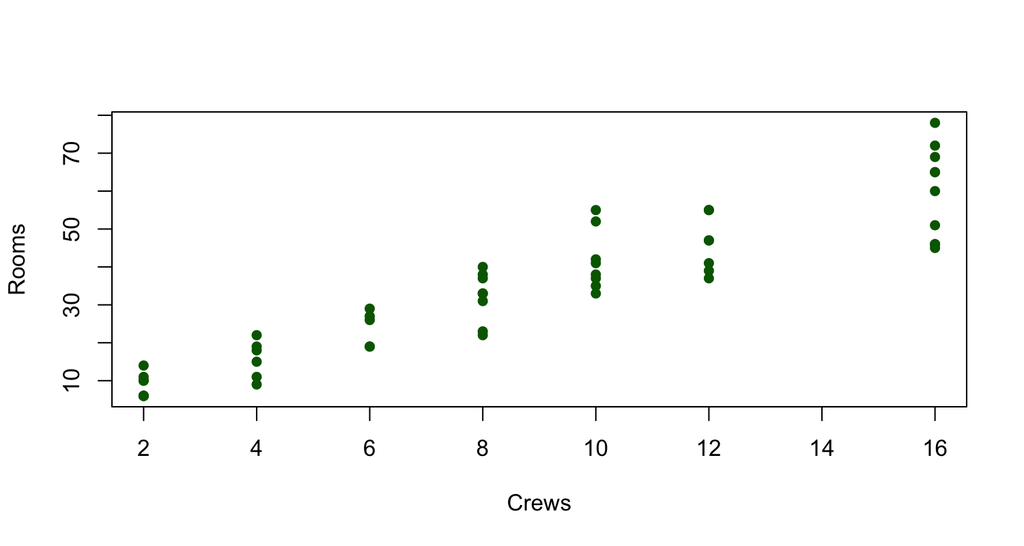

## Linear model?

```
            Estimate Std. Error    t value     Pr(>|t|)
(Intercept) 1.784699  2.0964798  0.8512835 3.985914e-01
Crews       3.700893  0.2118172 17.4721075 3.554200e-23
```

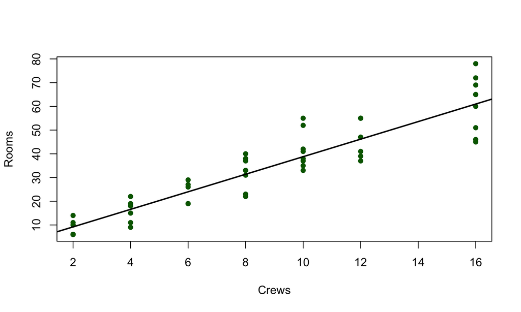

## Linearity and normality

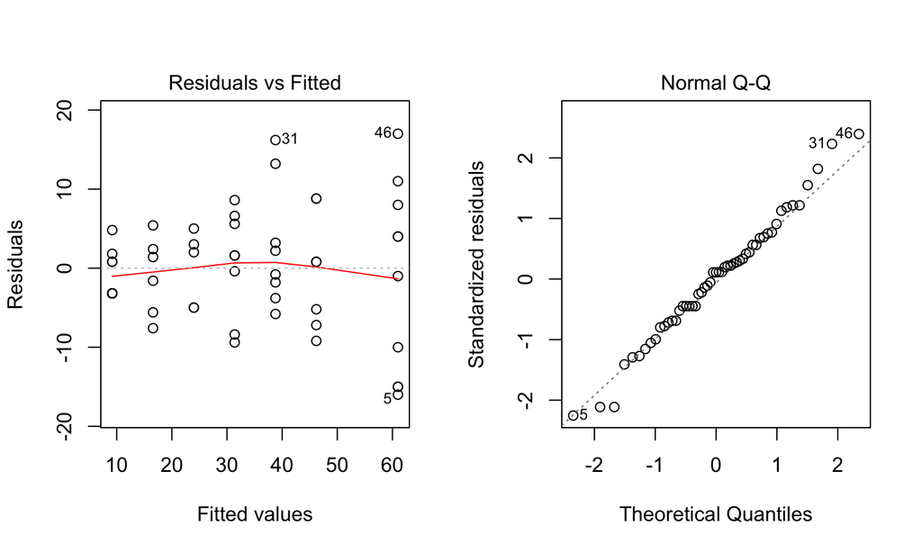

The mean function appears to be linear and the residuals are well-approximated by the normal distribution.

## Constant variance and influence

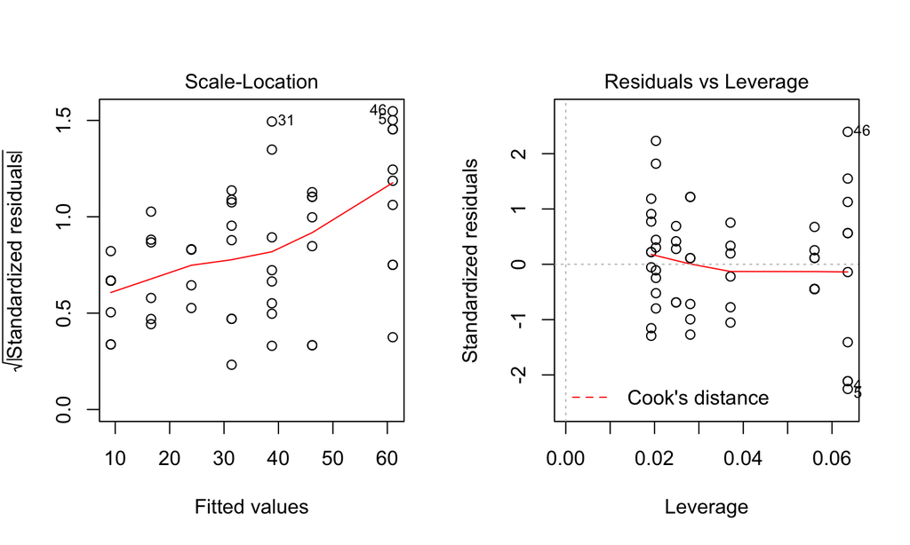

There are no influential points, however there is dramatic increasing variance.

## PIs on an invalid model

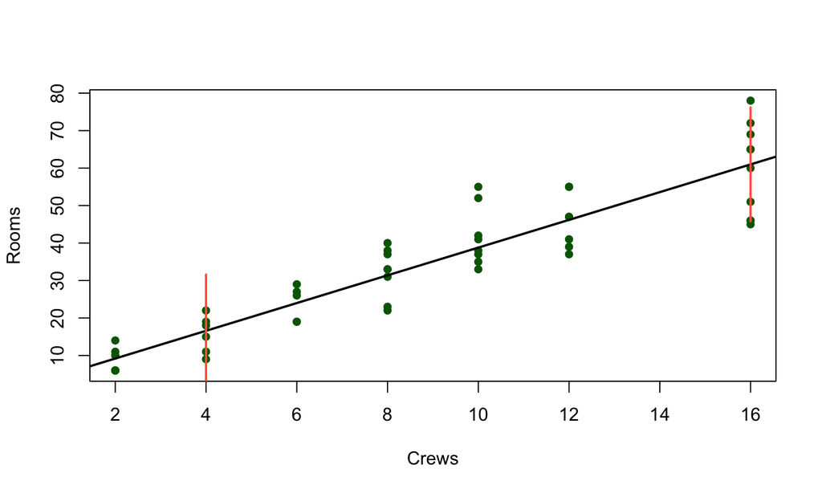

Prediction intervals are particularly sensitive to model assumptions, so we have good reason to distrust this one.

## Square root transform

The square root tranform is often useful to reducing the increasing variance that is found in many types of count data.

\[ X_t = \sqrt{X} \]

Let's transform both \(X\) and \(Y\).

```r
cleaning2 <- transform(cleaning, sqrtCrews = sqrt(Crews))
cleaning2 <- transform(cleaning2, sqrtRooms = sqrt(Rooms))
cleaning2[1:2, ]
```

```
  Case Crews Rooms sqrtCrews sqrtRooms
1    1    16    51  4.000000  7.141428
2    2    10    37  3.162278  6.082763
```

## Transformed linear model?

```
             Estimate Std. Error    t value     Pr(>|t|)
(Intercept) 0.2001232 0.27575417  0.7257306 4.713213e-01
sqrtCrews   1.9015814 0.09360113 20.3157951 4.202999e-26
```

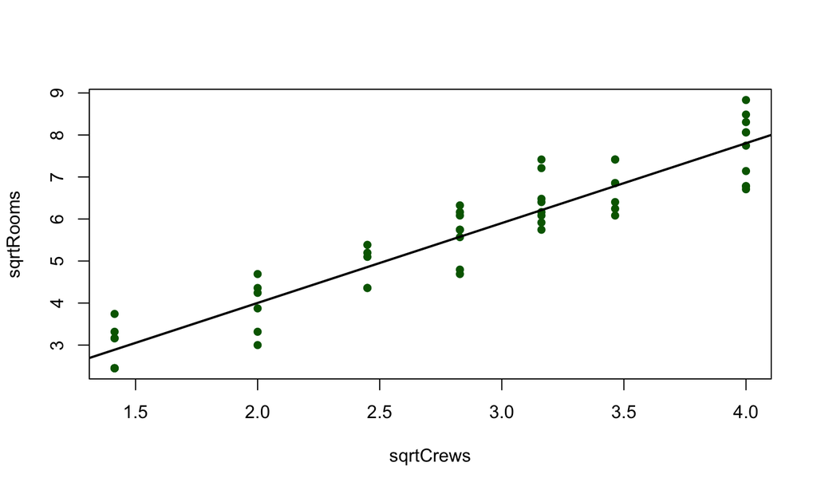

## Linearity and normality

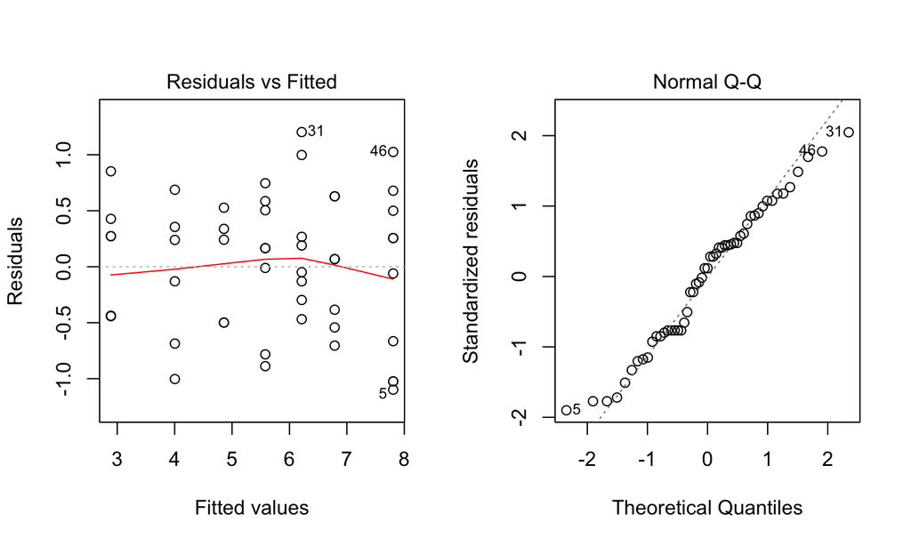

The mean function appears to be linear and the residuals are well-approximated by the normal distribution.

## Constant variance and influence

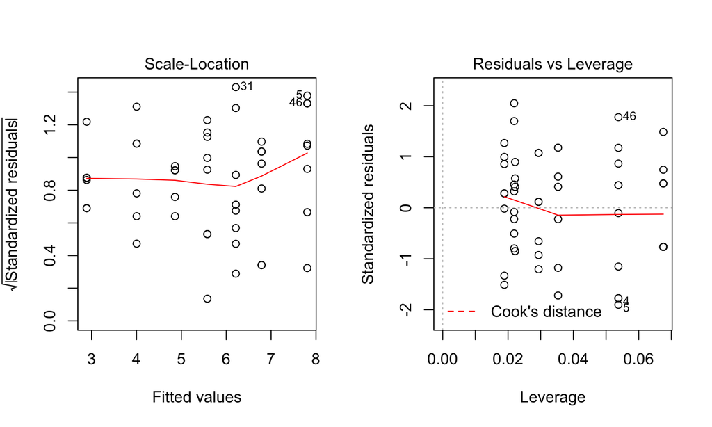

There are no influential points and the variance has been stabilized.

## PIs from a valid model

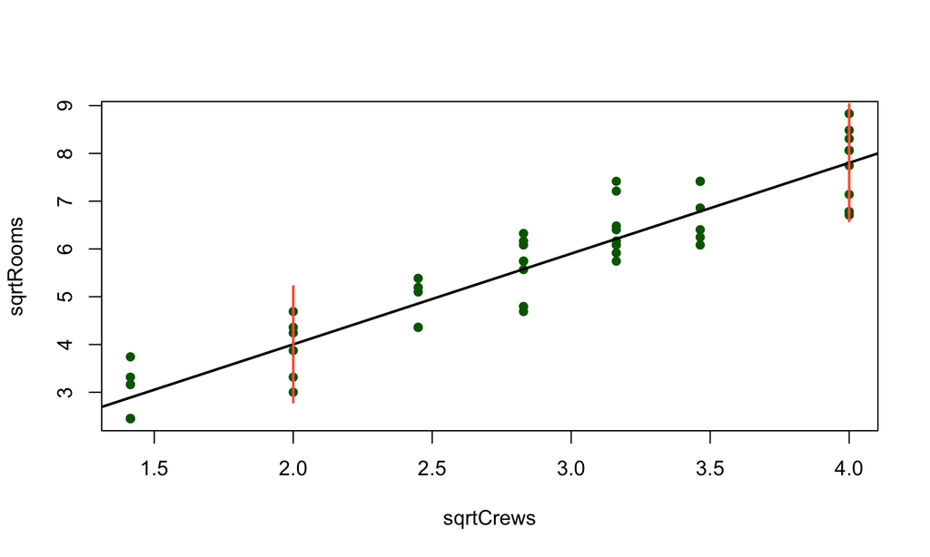

## Comparing PIs

```r
pi
```

```
       fit      lwr      upr
1 16.58827  1.58941 31.58713
2 60.99899 45.81025 76.18773
```

```r
pi2^2
```

```
       fit       lwr      upr
1 16.02630  7.783689 27.21339
2 60.94065 43.326931 81.55135
```

## Log Transformations

## Example 2: Truck prices

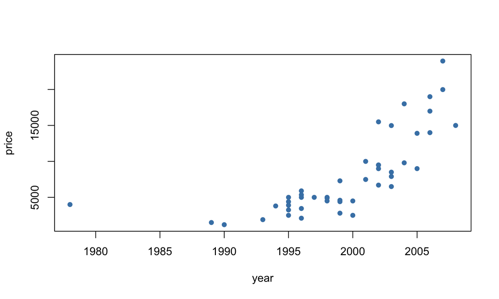

## Consider unusual observations

The very old truck will be a high leverage point and may not be of interest to model. Let's only consider trucks made in the last 20 years.

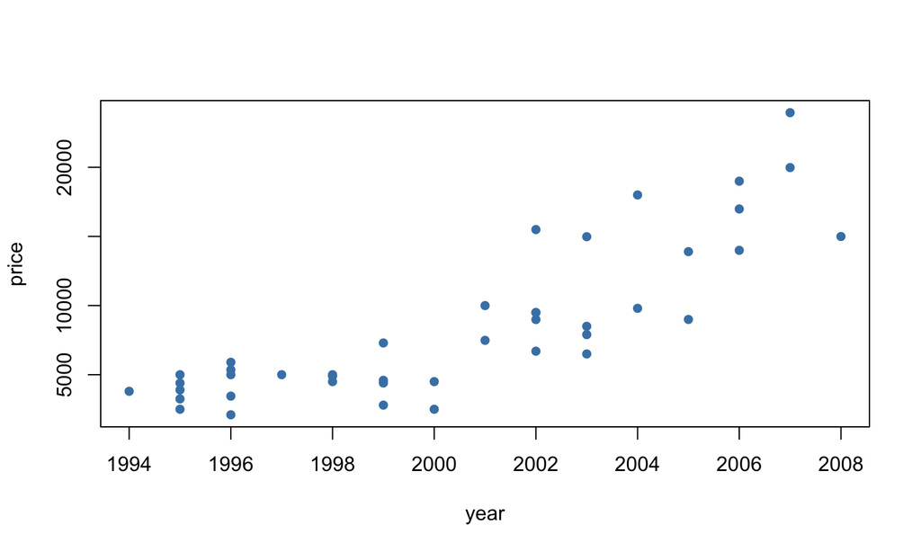

## Linear nodel?

```
                Estimate  Std. Error   t value     Pr(>|t|)
(Intercept) -2278766.230 238325.6991 -9.561563 6.923503e-12
year            1143.367    119.1371  9.597075 6.237638e-12
```

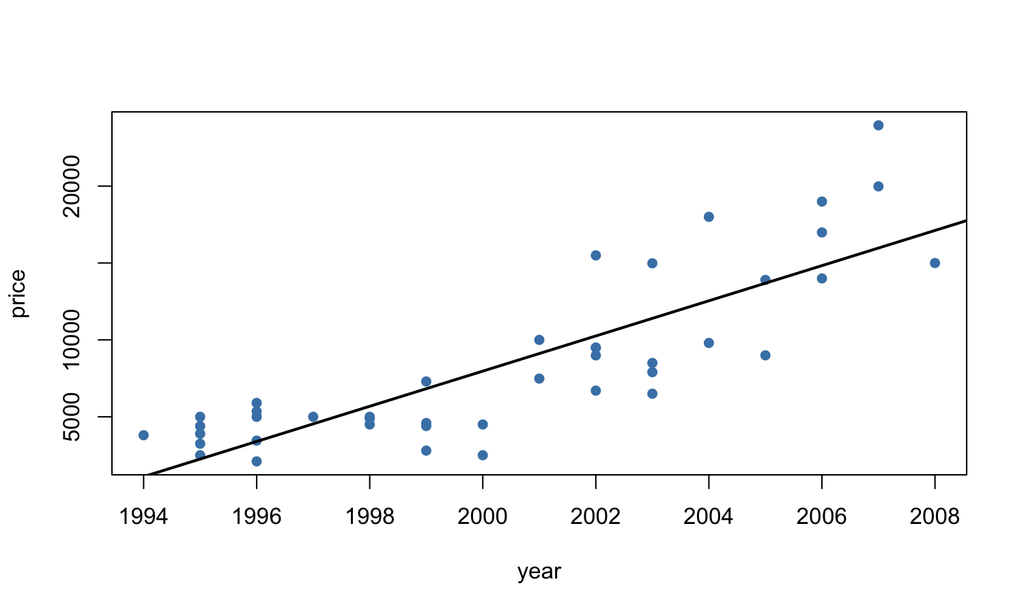

## Linearity and normality

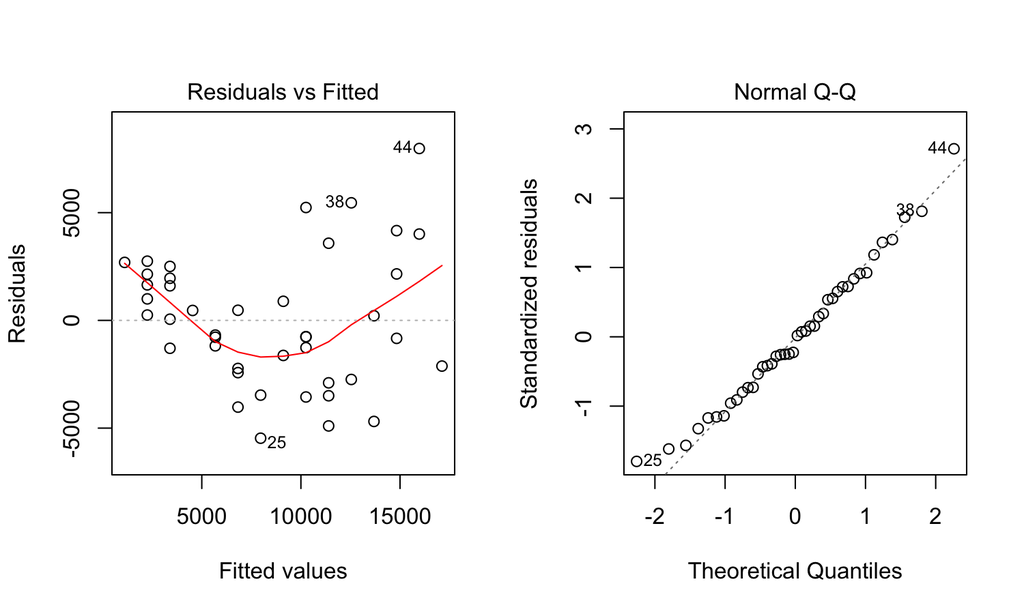

The normality assumption on the errors seems fine but there seems to be a quadratic trend in the mean function.

## Constant variance and influence

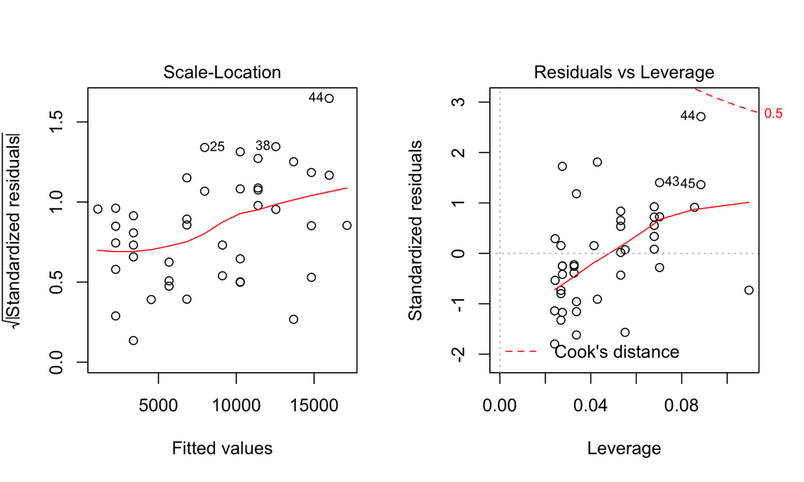

One observation (44) should be investigated for its influence. There is evidence of increasing variance in the residuals.

```r
pickups2 <- transform(pickups, log_price = log(price))
```

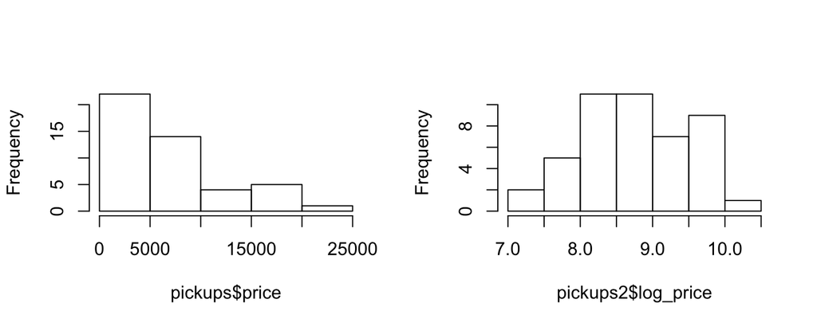

Variables that span multiple orders of magnitude often benefit from a natural log transformation.

\[ Y_t = log_e(Y) \]

## Log-transformed linear model

```
                Estimate  Std. Error   t value     Pr(>|t|)
(Intercept) -258.9980504 26.12294226 -9.914582 2.471946e-12
year           0.1338934  0.01305865 10.253239 9.342855e-13
```

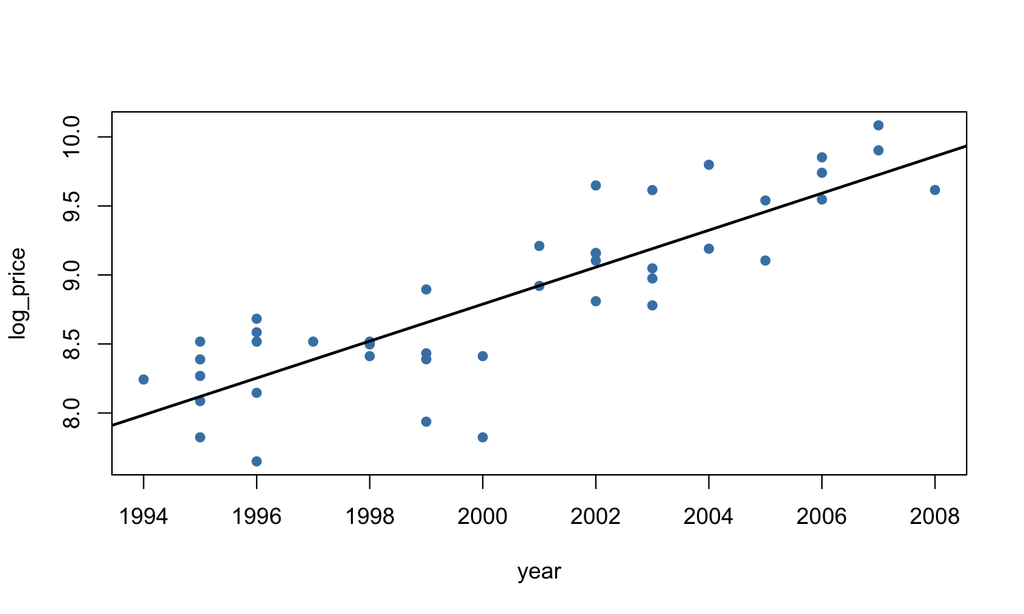

## Linearity and normality

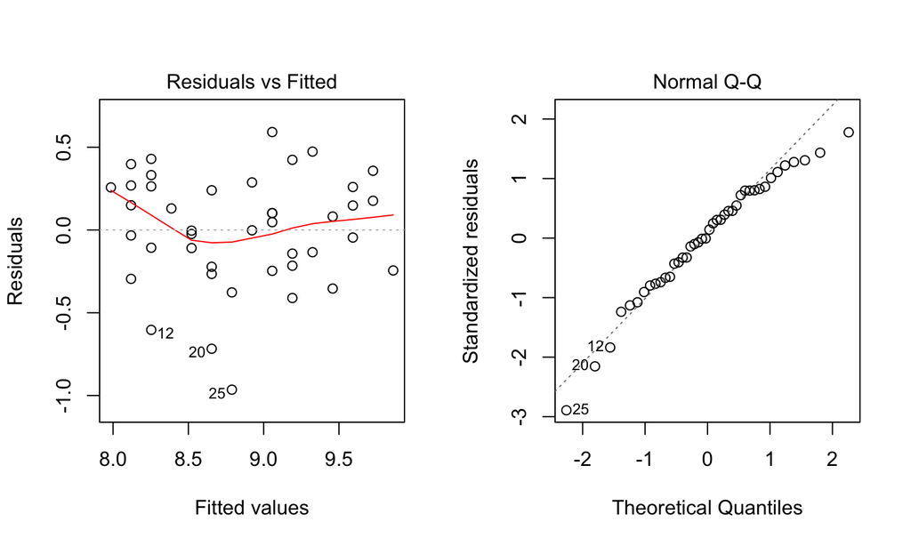

The residuals from this model appear less normal, though the quadratic trend in the mean function is now less apparent.

## Constant variance and influence

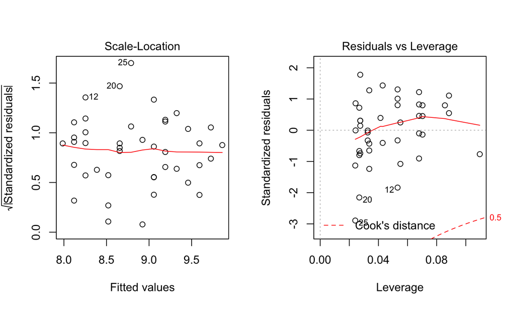

There are no points flagged as influential and our variance has been stabilized.

## Model interpretation

```
                Estimate  Std. Error   t value     Pr(>|t|)
(Intercept) -258.9980504 26.12294226 -9.914582 2.471946e-12
year           0.1338934  0.01305865 10.253239 9.342855e-13
```

\[ \widehat{log(price)} = -258.99 + 0.13 * year \]

Which isn't very useful . . .

## Working with logs

Two useful identities:

- \[ log(a) - log(b) = log(\frac{a}{b}) \]
- \[ e^{log(x)} = x \]

The slope coefficient for the log-transformed model is 0.13, meaning the *log* price difference between cars that are one year apart is predicted to be 0.13 log dollars.

\[ \begin{eqnarray} log(price at year x + 1) - log(price at year x) &=& 0.13 \\ log(\frac{price at year x + 1}{price at year x}) &=& 0.13 \\ e^{log(\frac{price at year x + 1}{price at year x})} &=& e^{0.13} \\ \frac{price at year x + 1}{price at year x} = 1.14 \\ \end{eqnarray} \]

For each additional year the car is newer we would expect the price of the car to increase on average by a factor of 1.14.

## Transformations summary

- If a linear model fit to the raw data leads to questionable residual plots, consider transformations.
- Count data and prices often benefit from transformations.
- The natural log and the square root are the most common, but you can use any transformation you like.
- Transformations may change model interpretations.
- Non-constant variance is a serious problem but it can often be solved by transforming the response.
- Transformations can also fix non-linearity, as can polynomials - coming next!

## Polynomials

## Multiple Regression: polynomials

Multiple regression refers to the method of predicting one variable as a linear function of more than one predictor.

*LA home price example*:

\[ \widehat{price} = \beta_0 + \beta_1 sqft + \beta_2 bath \]

But we could also introduc as the additional predictor a polynomial term of the existing predictor.

\[ \widehat{price} = \beta_0 + \beta_1 sqft + \beta_2 sqft^2 \]

## LA home prices

\[ \widehat{logprice} = \beta_0 + \beta_1 logsqft \]

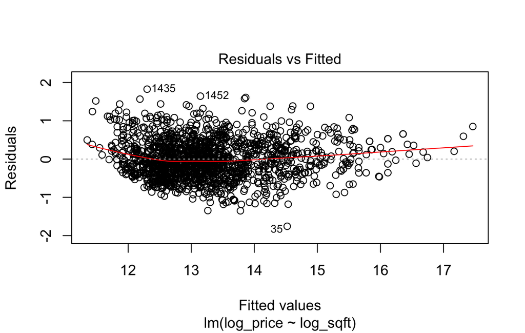

-doesn't look quite right

## Quadratic Model

We could consider adding a quadratic term to our model:

\[ \widehat{price} = \beta_0 + \beta_1 sqft + \beta_2 sqft^2 \]

```r
m2 <- lm(log_price ~ log_sqft + I(log_sqft^2), data = LA)
summary(m2)$coef
```

```
                Estimate Std. Error   t value     Pr(>|t|)
(Intercept)   10.2473942 1.17846431  8.695549 8.438387e-18
log_sqft      -0.5481929 0.30914337 -1.773264 7.637619e-02
I(log_sqft^2)  0.1300545 0.02016667  6.448984 1.489748e-10
```

## Comparing models

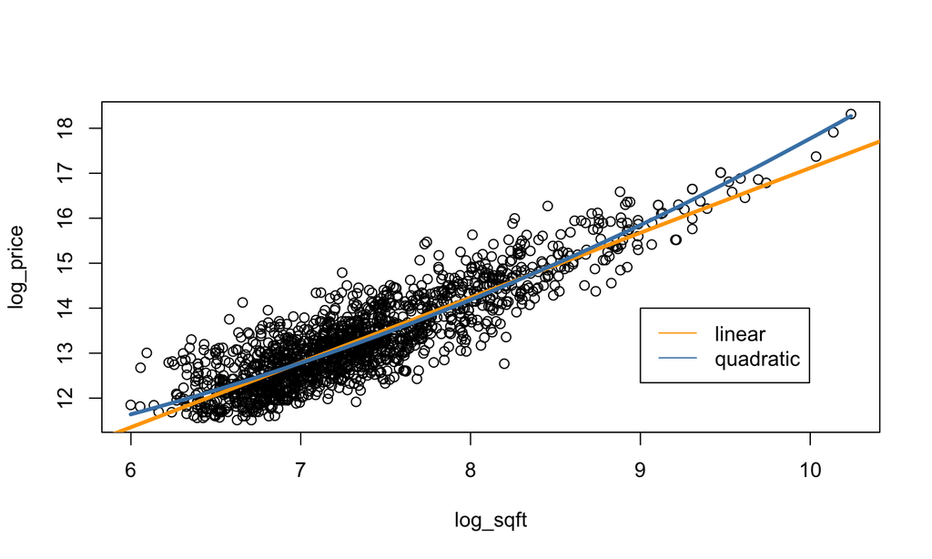

## Comparing models

```r
summary(m1)$coef
```

```
            Estimate Std. Error  t value     Pr(>|t|)
(Intercept) 2.702788 0.14369289 18.80948 1.972382e-71
log_sqft    1.441583 0.01953529 73.79375 0.000000e+00
```

```r
summary(m2)$coef
```

```
                Estimate Std. Error   t value     Pr(>|t|)
(Intercept)   10.2473942 1.17846431  8.695549 8.438387e-18
log_sqft      -0.5481929 0.30914337 -1.773264 7.637619e-02
I(log_sqft^2)  0.1300545 0.02016667  6.448984 1.489748e-10
```

## Linear model

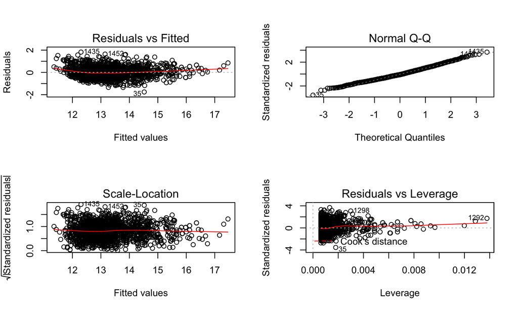

## Linear model with quadratic

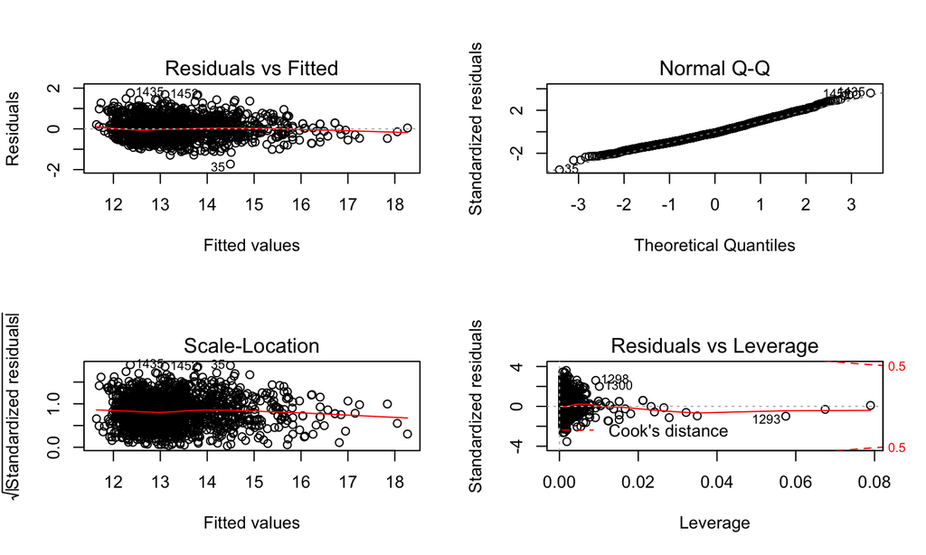

## Model selection

The residual plots for the second (more complex) model seem slightly better, so we're inclined to use that model. We can also compare the explanatory power of the models by looking at AIC, BIC, and adjusted \(R^2\).

```r
AIC(m1);AIC(m2)
```

```
[1] 2292.155
```

```
[1] 2253.023
```

```r
BIC(m1);BIC(m2)
```

```
[1] 2308.277
```

```
[1] 2274.519
```

```r
summary(m1)$adj;summary(m2)$adj
```

```
[1] 0.7736418
```

```
[1] 0.7792695
```

These two models are very similar - both are quite good in terms of validity and explanatory power - but the quadratic one edges out the simple linear one.

## Model selection

These are nested models, so we can use an F-test to see whether the model with the quadratic term is a significant improvement

```
Analysis of Variance Table

Model 1: log_price ~ log_sqft
Model 2: log_price ~ log_sqft + I(log_sqft^2)
  Res.Df    RSS Df Sum of Sq      F   Pr(>F)
1   1592 391.64
2   1591 381.67  1    9.9769 41.589 1.49e-10 ***
---
Signif. codes:  0 '***' 0.001 '**' 0.01 '*' 0.05 '.' 0.1 ' ' 1
```

We reject the null hypothesis that the coefficient for `logsqft^2` is equal to 0, and conclude that there is good evidence to support that the unrestricted model is better.

## Standardization

## Standardized coefficents

- A standardized regression coefficient is simply the () estimate from a regression on standardized variables.
- A standardized variable is a variable that has a mean of 0 and a standard deviation of 1.

## Why would we do this?

- One reason for standardizing variables is that you can interpret the () estimates as partial correlation coefficients.
- Now that the variables are standardized you can compare how correlated they are to the response variable using their regression coefficients.
- Example: you want to compare the relative impact of two variables that are in different units

## Let's make some fake data!

Let's simulate some data for running models. To provide a clear demonstration we need explanatory variables that are independent normal variates.

```r
set.seed(10)
n = 90
x1 = rnorm(n)
x2 = rnorm(n)
x3 = rnorm(n)
#create noise b/c there is always error in real life
epsilon = rnorm(n, 0, 3)
#generate response: additive model plus noise, intercept=0
y = 2*x1 + x2 + 3*x3 + epsilon
#organize predictors in data frame
sim_data = data.frame(y, x1, x2, x3)
```

The `scale()` function standardizes the independent and dependent variables (mean center and divide by sd)

```
         term estimate std.error statistic      p.value
1 (Intercept) 1.089282 0.3203666  3.400110 1.023378e-03
2          x1 2.070588 0.3360609  6.161347 2.248221e-08
3          x2 1.088801 0.3272882  3.326736 1.293995e-03
4          x3 3.579638 0.3231754 11.076455 3.093407e-18
```

```
         term     estimate  std.error    statistic      p.value
1 (Intercept) 4.418568e-18 0.06326165 6.984592e-17 1.000000e+00
2          x1 3.933853e-01 0.06384728 6.161347e+00 2.248221e-08
3          x2 2.117454e-01 0.06364960 3.326736e+00 1.293995e-03
4          x3 7.068502e-01 0.06381556 1.107645e+01 3.093407e-18
```

- The t-statistics (and p-values) don't change (but why is intercept 0?).
- t-statistic is a pivotal statistic; its value doesn't depend on the scale of the difference

## How to standardize

Traditionally, standardization is done as:

\[stdVar_i = (var_i - \bar(var)) / sd_{var} \]

in R, you can use `scale` or do the same thing by hand.

However, there is no rule that this has to be the case

## Centering

- Centering: `centeredA = scale(A,scale=F)`
- Centering decides where the baseline will be for your model
  - You can subtract the mean
  - Also possible to subtract meaningful value

## Scaling

- Scaling: `scaleA = scale(A,scale=T)`
- Scaling changes the unit of the predictor variable
  - Divide by meaningful unit
  - Divide by standard deviation (combined with mean centering gives you z-score )
  - Divide by 2 standard deviation ( coherent estimate when you have binary variable )

## Why divide by 2 sd?

- Andy Gelman (my favorite statistician) favors dividing by **2** standard deviations
- Interpretation of regression coefficients is sensitive to the scale of the inputs.
- Dividing by `2*sd` sets interpretation of coefficient to be "if X goes from 1 standard deviation below the mean to 1 standard deviation above the mean…"
- i.e., if X goes from low to high….
- This makes resulting coefficients directly comparable to untransformed binary predictors

## Does and dont's

- Often, you will combine transformations and standardizations
- do not subtract the mean and rescale an input variable before it has been logged (logged inputs and outputs are interpretated “elasticities” - rescaling muddies this)
- scale first, then interact
- do not scale categorical variables or binary variables

## wrap-up

Questions?

Goal check

Motivation for next class

[output not shown]